# Assignment 3

Nick McManus

3 March 2023

# Task 1

Compute the mean and max power for 4 cars, assuming that average highway speed is 80 kph with a std dev of 10 kph. Do this with both a for loop and `purrr::pmap`.

4 car types:

```r
### read in auto power and speed conversion functions
source(here("Assignments/R/apg_function.R"))
source(here("Assignments/R/mps_conv_function.R"))

### create dataframe with cars
possible_cars <- data.frame(name = c("A","B","C","D"),
                            mass = c(10000, 65000, 38000, 5000),
                            area = c(22, 30, 22, 10))

### convert avg speed to mps
base_speed <- mps_conv(80)

possible_cars$power = apg(v=base_speed,
                          sa = possible_cars$area,
                          m=possible_cars$mass)

# head(possible_cars)
```

## For loop:

```r
### create sample size
nsample = 200
### convert kph to log mps for average speed
mean_speed = log(base_speed)
### find log normal distribution
speeds = rlnorm(mean=mean_speed, sd=0.08*mean_speed, nsample)

### explore speed data
# summary(speeds)
# plot(density(speeds), ylab="Distribution of Speeds in (m/s)")

### create empty dataframe to store for loop results
### 4 columns for each car and 200 rows for each observed speed
powerall = as.data.frame(matrix(nrow = length(speeds),
                                ncol = nrow(possible_cars)))

### now run for loop using data from `possible_cars`
for (i in 1:length(powerall)) {
  powerall[,i] = apg(m = possible_cars$mass[i],
                     v = speeds,
                     sa = possible_cars$area[i])
}

### add column names
colnames(powerall) = possible_cars$name

### turn columns in to rows for plotting and finding means
powerallr = powerall %>%
  pivot_longer(cols = everything(),
               names_to = "car",
               values_to = "power")

### Find mean powers and return in nice table
means_floop <- powerallr %>%
  group_by(car) %>%
  summarize(mean = mean(power),
            median = median(power),
            max = max(power))

means_floop %>%
  kable(caption = "**Table 1.** Sample statistics for car powers using for-loop method",
        col.names = c("Car", "Mean power", "Median power", "Max power")) %>%
  kable_styling(full_width = FALSE,
                bootstrap_options = "hover",
                position = "left")
```

**Table 1.** Sample statistics for car powers using for-loop method

| Car | Mean power | Median power | Max power |
| --- | --- | --- | --- |
| A | 93911.04 | 82967.29 | 393508.8 |
| B | 304297.52 | 287743.76 | 866180.5 |
| C | 189983.61 | 178151.03 | 573172.4 |
| D | 44246.46 | 39257.59 | 181784.3 |

## Pmap:

Next, we’ll find the mean and max on the same sample size of cars and speeds using `purrr::pmap`

```r
### use same speed data as for loop

### run pmap
powerall2 = pmap(list(sa = possible_cars$area,
                      m = possible_cars$mass),
                 apg, v = speeds)

### convert pmap results into dataframe
powerall2 = as.data.frame(powerall2,
                          col.names = possible_cars$name)

### turn columns in to rows for plotting and finding means
powerallr2 = powerall2 %>%
  pivot_longer(cols = everything(),
               names_to = "car",
               values_to = "power")

### Find mean powers and return in nice table
means_pmap <- powerallr2 %>%
  group_by(car) %>%
  summarize(mean = mean(power),
            median = median(power),
            max = max(power))

means_pmap %>%
  kable(caption = "**Table 2.** Sample statistics for car powers using pmap method",
        col.names = c("Car", "Mean power", "Median power", "Max power")) %>%
  kable_styling(full_width = FALSE,
                bootstrap_options = "hover",
                position = "left")
```

**Table 2.** Sample statistics for car powers using pmap method

| Car | Mean power | Median power | Max power |
| --- | --- | --- | --- |
| A | 93911.04 | 82967.29 | 393508.8 |
| B | 304297.52 | 287743.76 | 866180.5 |
| C | 189983.61 | 178151.03 | 573172.4 |
| D | 44246.46 | 39257.59 | 181784.3 |

# Task 2

Create two boxplots (one for each method) that show the range of power consumption across sampled speeds by car type.

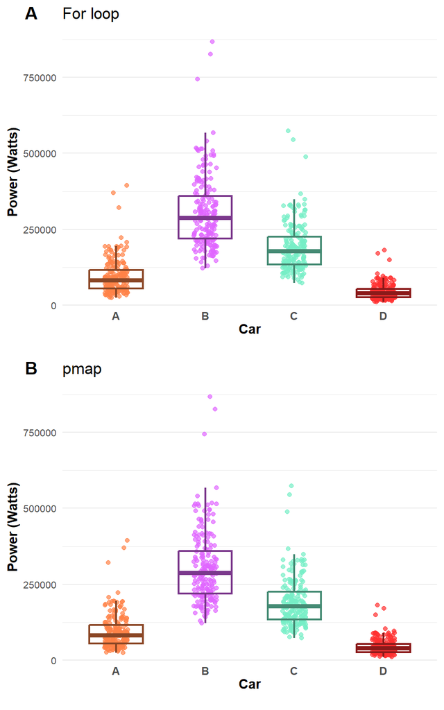

```r
forLoop_plot <- ggplot(data = powerallr,
                       aes(x = car, y = power)) +
  geom_jitter(aes(color = car), width = .13, alpha = 0.7, size = 1.5) +
  scale_color_manual(values = c("sienna1", "mediumorchid1", "aquamarine2", "firebrick1")) +
  geom_boxplot(fill = NA, outlier.color = NA, width = 0.6, lwd = 0.8,
               color = c("sienna4", "mediumorchid4", "aquamarine4", "firebrick4")) +
  labs(x = "Car",
       y = "Power (Watts)",
       title = "For loop") +
  theme_minimal() +
  theme(
    panel.grid.major.x = element_blank(),
    axis.title.x = element_text(vjust = 5, face = 'bold'),
    axis.title.y = element_text(face = 'bold'),
    axis.text.x = element_text(vjust = 5, face = 'bold', size = 9),
    axis.text.y = element_text(size = 8),
    legend.position = 'none')



pmap_plot <- ggplot(data = powerallr2,
                    aes(x = car, y = power)) +
  geom_jitter(aes(color = car), width = .13, alpha = 0.7, size = 1.5) +
  scale_color_manual(values = c("sienna1", "mediumorchid1", "aquamarine2", "firebrick1")) +
  geom_boxplot(fill = NA, outlier.color = NA, width = 0.6, lwd = 0.8,
               color = c("sienna4", "mediumorchid4", "aquamarine4", "firebrick4")) +
  labs(x = "Car",
       y = "Power (Watts)",
       title = "pmap") +
  theme_minimal() +
  theme(
    panel.grid.major.x = element_blank(),
    axis.title.x = element_text(vjust = 5, face = 'bold'),
    axis.title.y = element_text(face = 'bold'),
    axis.text.x = element_text(vjust = 5, face = 'bold', size = 9),
    axis.text.y = element_text(size = 8),
    legend.position = 'none')

ggarrange(forLoop_plot, pmap_plot,
          labels = c("A", "B"),
          hjust = -2,
          nrow=2)
```

**Figure 1.** The range of power consumption for four cars with differing mass and surface area. Power consumption was calculated based on a sample of 200 log normally distributed highway speeds. Fig 1a displays the results using a for loop method, while Fig 1b shows the results using pmap. Both methods produced identical results, with a mean power consumption of 9.391104^{4}, 3.0429752^{5}, 1.8998361^{5} and 4.4246456^{4} for Cars A, B, C and D, respectively.

As displayed in Figure 1 and Tables 1 and 2, the power consumption values are identical for both methods. The range of power consumption for each car is positively skewed, with a mean greater than the median. This is because power consumed is a function of speed cubed. Even for a log-normal distribution of speeds, those on the higher end result in exponentially greater power consumption.